# Homeworks

Zhang Jin 20007

2020/12/18

# Assert

In order to shorten the compile time of the vignette, I reduce the sample size or forbid running of several exercises comparing with my assignment submitted. To be specific, the difference will be listed down below:

Reduction of sample size:

1. Homework 5, Exercise 6.C, I reduce the two sample sizes 1000 and 100 respectively to 100 and 30.

Forbiddance of running:

1. Homework 7, Discussion
2. Homework 8, Gelman-Rubin method.

# Homework 1 (2020-09-22)

## Question

Use knitr to produce 3 examples in the book. The 1st example should contain texts and at least one figure. The 2nd example should contains texts and at least one table. The 3rd example should contain at least a couple of LaTeX formulas.

## Answer

### (1)

In my first example, I used lattice package to make density plot. For the randomly generated data, I plotted both empirical density curve and normal fitting curve.

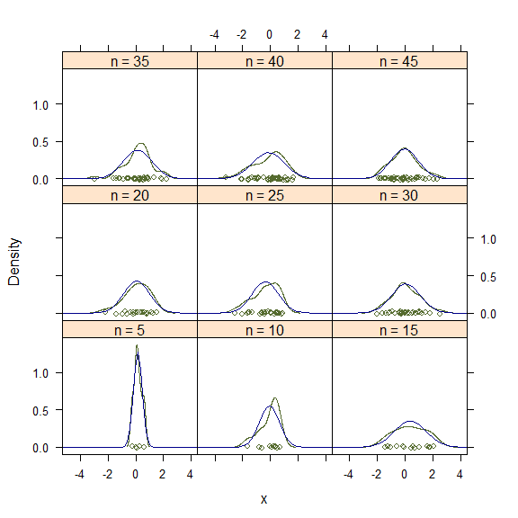

```r
library(lattice)
n <- seq(5, 45, 5)
x <- rnorm(sum(n))
y <- factor(rep(n, n), labels=paste("n =", n))
densityplot(~ x | y,
panel = function(x, ...) {
panel.densityplot(x, col="DarkOliveGreen", ...)
panel.mathdensity(dmath=dnorm,
args=list(mean=mean(x), sd=sd(x)),
col="darkblue")
})
```

### (2)

In my second example, I used some methods to deal with the longitudinal data of some patients.

```r
stdv = function(x) {  if (NROW(x)>1)   sigma <- round(sd(x),2)
                                   else   sigma <- 0
                                   sigma }
smry <- function(X){     mu <- apply(X,2,mean)
sigma <- apply(X,2,stdv)
c(mu=mu,sigma=sigma)}

patients <- c("0071021198307012008001400400150",
                       "0071201198307213009002000500200",
                      "0090903198306611007013700300000",
                      "0050705198307414008201300900000",
                     "0050115198208018009601402001500",
                     "0050618198207017008401400800400",
                     "0050703198306414008401400800200")
id <- substr(patients,1,3)    # First 3 digits signify the patient ID
date <- as.Date(substr(patients,4,11), format = "%m%d%Y")    # 4-11 for treatment date
hr <- as.numeric(substr(patients,12,14))    # Heart rate
sbp <- as.numeric(substr(patients,15,17))    # Systolic blood pressure
dbp <- as.numeric(substr(patients,18,20))    # Diastolic blood pressure
dx <- substr(patients,21,23)
docfee <- as.numeric(substr(patients,24,27))
labfee <- as.numeric(substr(patients,28,31))

tapply(hr, id, mean)
```

```
## 005 007 009
##  72  71  66
```

```r
tapply(hr, id, stdv)
```

```
##  005  007  009
## 6.73 1.41 0.00
```

```r
# Show these results in a more compact way
PATIENTS <- data.frame(id, hr, sbp, dbp, docfee, labfee)
str(PATIENTS)
```

```
## 'data.frame':    7 obs. of  6 variables:
##  $ id    : chr  "007" "007" "009" "005" ...
##  $ hr    : num  70 72 66 74 80 70 64
##  $ sbp   : num  120 130 110 140 180 170 140
##  $ dbp   : num  80 90 70 82 96 84 84
##  $ docfee: num  40 50 30 90 200 80 80
##  $ labfee: num  150 200 0 0 1500 400 200
```

```r
smry(PATIENTS[id=='005',2:6])
```

```
##        mu.hr       mu.sbp       mu.dbp    mu.docfee    mu.labfee     sigma.hr
##        72.00       157.50        86.50       112.50       525.00         6.73
##    sigma.sbp    sigma.dbp sigma.docfee sigma.labfee
##        20.62         6.40        58.52       670.20
```

```r
smry(PATIENTS[id=='007',2:6])
```

```
##        mu.hr       mu.sbp       mu.dbp    mu.docfee    mu.labfee     sigma.hr
##        71.00       125.00        85.00        45.00       175.00         1.41
##    sigma.sbp    sigma.dbp sigma.docfee sigma.labfee
##         7.07         7.07         7.07        35.36
```

```r
smry(PATIENTS[id=='009',2:6])
```

```
##        mu.hr       mu.sbp       mu.dbp    mu.docfee    mu.labfee     sigma.hr
##           66          110           70           30            0            0
##    sigma.sbp    sigma.dbp sigma.docfee sigma.labfee
##            0            0            0            0
```

```r
by(PATIENTS[2:6], id, smry)
```

```
## id: 005
##        mu.hr       mu.sbp       mu.dbp    mu.docfee    mu.labfee     sigma.hr
##        72.00       157.50        86.50       112.50       525.00         6.73
##    sigma.sbp    sigma.dbp sigma.docfee sigma.labfee
##        20.62         6.40        58.52       670.20
## ------------------------------------------------------------
## id: 007
##        mu.hr       mu.sbp       mu.dbp    mu.docfee    mu.labfee     sigma.hr
##        71.00       125.00        85.00        45.00       175.00         1.41
##    sigma.sbp    sigma.dbp sigma.docfee sigma.labfee
##         7.07         7.07         7.07        35.36
## ------------------------------------------------------------
## id: 009
##        mu.hr       mu.sbp       mu.dbp    mu.docfee    mu.labfee     sigma.hr
##           66          110           70           30            0            0
##    sigma.sbp    sigma.dbp sigma.docfee sigma.labfee
##            0            0            0            0
```

```r
by(PATIENTS[2:6], id, summary)
```

```
## id: 005
##        hr            sbp             dbp           docfee          labfee
##  Min.   :64.0   Min.   :140.0   Min.   :82.0   Min.   : 80.0   Min.   :   0
##  1st Qu.:68.5   1st Qu.:140.0   1st Qu.:83.5   1st Qu.: 80.0   1st Qu.: 150
##  Median :72.0   Median :155.0   Median :84.0   Median : 85.0   Median : 300
##  Mean   :72.0   Mean   :157.5   Mean   :86.5   Mean   :112.5   Mean   : 525
##  3rd Qu.:75.5   3rd Qu.:172.5   3rd Qu.:87.0   3rd Qu.:117.5   3rd Qu.: 675
##  Max.   :80.0   Max.   :180.0   Max.   :96.0   Max.   :200.0   Max.   :1500
## ------------------------------------------------------------
## id: 007
##        hr            sbp             dbp           docfee         labfee
##  Min.   :70.0   Min.   :120.0   Min.   :80.0   Min.   :40.0   Min.   :150.0
##  1st Qu.:70.5   1st Qu.:122.5   1st Qu.:82.5   1st Qu.:42.5   1st Qu.:162.5
##  Median :71.0   Median :125.0   Median :85.0   Median :45.0   Median :175.0
##  Mean   :71.0   Mean   :125.0   Mean   :85.0   Mean   :45.0   Mean   :175.0
##  3rd Qu.:71.5   3rd Qu.:127.5   3rd Qu.:87.5   3rd Qu.:47.5   3rd Qu.:187.5
##  Max.   :72.0   Max.   :130.0   Max.   :90.0   Max.   :50.0   Max.   :200.0
## ------------------------------------------------------------
## id: 009
##        hr          sbp           dbp         docfee       labfee
##  Min.   :66   Min.   :110   Min.   :70   Min.   :30   Min.   :0
##  1st Qu.:66   1st Qu.:110   1st Qu.:70   1st Qu.:30   1st Qu.:0
##  Median :66   Median :110   Median :70   Median :30   Median :0
##  Mean   :66   Mean   :110   Mean   :70   Mean   :30   Mean   :0
##  3rd Qu.:66   3rd Qu.:110   3rd Qu.:70   3rd Qu.:30   3rd Qu.:0
##  Max.   :66   Max.   :110   Max.   :70   Max.   :30   Max.   :0
```

```r
# Calculate the difference between the first and the last observations of HR, SBP and DBP
HrSbpDbp  <- data.frame(id, date, hr, sbp, dbp)
# Sort by ID first, then sort by treatment date
HrSbpDbpSorted <- HrSbpDbp[order(HrSbpDbp$id, HrSbpDbp$date), ]
HrSbpDbpSorted
```

```
##    id       date hr sbp dbp
## 5 005 1982-01-15 80 180  96
## 6 005 1982-06-18 70 170  84
## 7 005 1983-07-03 64 140  84
## 4 005 1983-07-05 74 140  82
## 1 007 1983-10-21 70 120  80
## 2 007 1983-12-01 72 130  90
## 3 009 1983-09-03 66 110  70
```

### (3)

In this example, I listed several theorems using some Latex copulas.

Levy CLT:

$\displaystyle\frac{\sqrt{n}(\bar{X} - \mu)}{\sigma} \stackrel{d}{\longrightarrow} N(0,1)$

Berry-Esseen CLT:

$\displaystyle\sup_{t} |G_n(t)-\Phi(t)| \leq C \frac{\rho}{\sigma^3 \sqrt{n}}$

Percentile CLT:

$\displaystyle\lim_{n \rightarrow \infty} P \Big( \frac{\sqrt{n} (\hat{\xi}_{pn}-\xi_p)}{\sqrt{p(1-p)}/F'(\xi_p -)} \leq t \Big) = \Phi(t)$

$~$

$~$

# Homework 2 (2020-09-29)

## Exercise 3.3

### Problem

The Pareto(a, b) distribution has cdf

$$\displaystyle F(x)=1-(\frac{b}{x})^a,~~~~~~~x \geq b >0,~a>0.$$

Derive the probability inverse transformation $F^{-1}(U)$ and use the inverse transform method to simulate a random sample from the Pareto(2,2) distribution. Graph the density histogram of the sample with the Pareto(2,2) density superimposed for comparison.

### Solution

First, for the cdf

$$\displaystyle F(x)=1-(\frac{b}{x})^a,~~~~~~~x \geq b >0,~a>0$$
,

I can derive its inverse

$$\displaystyle F^{-1}(x)=\frac{b}{\sqrt[a]{1-x}}~~~~~~~0 \leq x \leq 1,~a>0$$
,

Then I could generate random variables from Uniform(0,1).

I will simulate a sample number of 10000, $a=b=2$ as the exercise suggests.  
The pdf of the Pareto(a,b) distribution is

$$f(x)=\displaystyle \frac{ab^a}{x^{a+1}},~~~~~~~x \geq b >0,~a>0$$

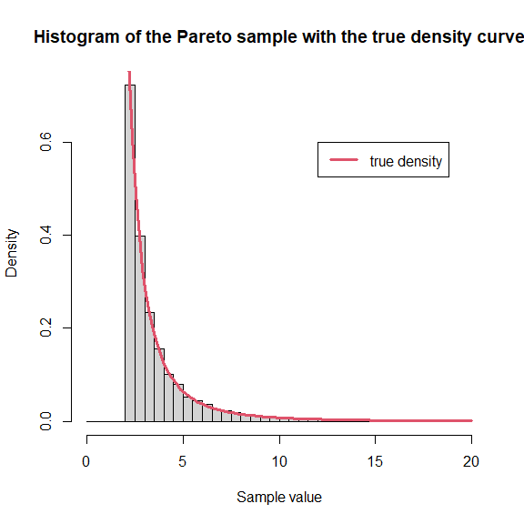

```r
n <- 10000
a <- 2
b <- 2
unifrv <- runif(n)
paretorv <- b/(1-unifrv)^(1/a)    # inverse transformation
hist(paretorv[paretorv>0 & paretorv<20], freq = FALSE, breaks = seq(0,20,0.5), main = "Histogram of the Pareto sample with the true density curve",xlab = "Sample value")    # graph the density histogram
# I found that F(20)=0.99, which is very close to 1. For the sake of the tidiness and better description for the feature of the histogram, I made a truncation on x=20, and only consider the variables between 0 and 20.
f <- function(x) {a*b^a/x^(a+1)}    # true pdf
curve(f, 2, 20, col = 2, lwd = 3, add = TRUE)    # add the true density curve
legend(12,0.6,"true density", col = 2, lwd = 3)    # add a legend
```

## Exercise 3.9

### Problem

The rescaled Epanechnikov kernel is a symmetric density function

$$\displaystyle f_e(x)=\frac{3}{4}(1-x^2),~~~~~~~|x| \leq 1$$

Devroye and Gyorfi give the following algorithm for simulation from this distribution. Generate iid $U_1,U_2,U_3 \sim$ Uniform(-1,1). If $|U_3|\geq|U_2|$ and $|U_3|\geq|U_1|$, deliver $U_2$; otherwise deliver |U_3|. Write a function to generate random variates from $f_e$, and construct the histogram density estimate of a large simulated random sample.

### Solution

Just do as the problem suggests. Consider a sample number of 10000.

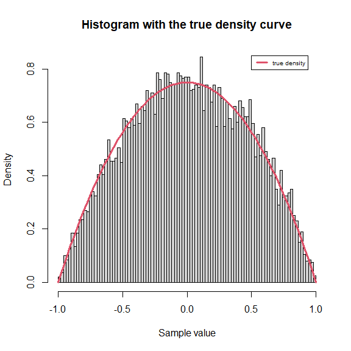

```r
u1 <- runif(10000, min = -1, max = 1)    # consider a sample number of 10000
u2 <- runif(10000, min = -1, max = 1)
u3 <- runif(10000, min = -1, max = 1)
u <- ifelse((abs(u3)>abs(u2) & abs(u3)>abs(u1)), u2, u3)
hist(u, freq = FALSE, breaks = seq(-1,1,0.02), main = "Histogram with the true density curve", xlab = "Sample value")
f <- function(x) {3/4*(1-x^2)}
curve(f, -1, 1, col = 2, lwd = 3, add = TRUE)    # add the true density curve
legend(0.5,0.85,"true density", col = 2, lwd = 3, cex=0.6)    # add a legend
```

## Exercise 3.10

### Problem

Prove that the algorithm given in Exercise 3.9 generates variates from the density $f_e$

### Solution

Let $X_1=|U_1|, X_2=|U_2|, X_3=|U_3|$,then clearly there is $X_1,X_2,X_3 \sim$ Uniform(0,1).

Let $X= \begin{cases} X_2 & ~~X_3 \geq X_1~~and~~ X_3 \geq X_2 \\ X_3 & ~~otherwise \\ \end{cases}$
Then, since $f_e(x)$ is symmetric, all I have to prove is that $X$ obeys the pdf
$$f_{e'}(x)=2*\frac{3}{4}(1-x^2),~~~~~~~0 \leq x \leq 1$$

Now, notice that the algorithm to generate $X$ can be rewritten as:

1. Generate $X_1,X_2,X_3 \sim$ Uniform(0,1).
2. Remove the largest value $X_{(3)}$
3. Select one of the remaining two values with equal probability. Let $X$ be this value.

For any $0 \leq x \leq 1$, consider the events:  
$A=\{$ only one of the $X_i \leq x$ $\}$  
$B=\{$ at least two of the $X_i \leq x$ $\}$,  
Then, it’s easy to compute the cdf of $X$, $F_{e'}(x)$ as following:

$$\begin{align}
F_{e'}(x)&=P(X\leq x)\\
&=P(X \leq x,A)+P(X \leq x,B)\\
&=P(X \leq x~|~A)*P(A) + P(X \leq x~|~B)*P(B)\\
&=\frac{1}{2}*3x(1-x)^2 + 1*[3x^2(1-x) + x^3]\\
&=-\frac{1}{2} x^3 +\frac{3}{2}x,~~~~~~0 \leq x \leq 1
\end{align}$$

Thus, the pdf of $X$ is
$$f_{e'}(x)=F'_{e'}(x)=2*\frac{3}{4}(1-x^2),~~~~~~~0 \leq x \leq 1$$

Thus, the algorithm given in Exercise 3.9 generates variates from the density $f_e. ~~~ \Box$

## Exercise 3.13

### Problem

It can be shown that the mixture in Exercise 3.12 has a Pareto distribution with cdf
$$F(y)=1-\Big(\frac{\beta}{\beta+y}\Big)^r,~~~~~~~y\geq0$$

(This is an alternative parameterization of the Pareto cdf given in Exercise 3.3.) Generate 1000 random observations from the mixture with $r=4$ and $\beta=2$. Compare the empirical and theoretical (Pareto) distributions by graphing the density histogram of the sample and superimposing the Pareto density curve.

# Homework 3 (2020-10-13)

## Exercise 5.1

### Problem

Compute a Monte Carlo estimate of
$$\int_0^{\pi/3} sin~t~dt$$
and compare your estimate with the exact value of the integral.

### Solution

Use the simple Monte Carlo integration.
$$X \sim Uniform(0,\pi/3),~~~g(X)=\pi sin(X)/3$$
The exact value is
$$\int_0^{\pi/3} sin~t~dt=cos(0)-cos(\pi/3)=0.5$$

```r
set.seed(3333)
monte_carlo_rep <- 100000
uniform_x <- runif(monte_carlo_rep,0,pi/3)
single_estimate <- sin(uniform_x)*pi/3
final_estimate <- mean(single_estimate)
final_estimate
```

```
## [1] 0.5006204
```

```r
#=0.5006204, very close to the exact value 0.5.
```

## Exercise 5.7

### Problem

Refer to Exercise 5.6. Use a Monte Carlo simulation to estimate $\theta$ by the antithetic variate approach and by the simple Monte Carlo method. Compute an empirical estimate of the percent reduction in variance using the antithetic variate. Compare the result with the theoretical value from Exercise 5.6

### Solution

$$\theta=\int_0^1 e^xdx$$
$$Var(e^U)=E(e^{2U})-(E(e^U))^2=\int_0^1 e^{2x}dx-(\int_0^1 e^{x}dx)^2=\frac{1}{2}(e^2-1)-(e-1)^2=0.2420$$
$$Cov(e^U,e^{1-U})=E(e^{U+1-U)})-E(e^U)E(e^{1-U})=e-\int_0^1e^xdx \int_0^1e^{1-x}dx=-0.2342$$
$$Var((e^U+e^{1-U})/2)=Var(e^U)/4+Var(e^{1-U})/4+Cov(e^U,e^{1-U})/2=0.0039$$

Thus, the theoretical value of percent reduction is $1-0.0039/0.2420=98.39\%$

Next, we could compute an empirical estimate of the percent reduction in variance by the Monte Carlo simulation.

```r
set.seed(2222)
monte_carlo_r <- 100
var_reduc_store <- rep(0,monte_carlo_r)
for (i in 1:monte_carlo_r){
  u <- runif(10000)
  simple_mc <- exp(1)^u
  antithetic <- (exp(1)^u+exp(1)^(1-u))/2
  var_reduc_store[i] <- 1- var(antithetic) / var(simple_mc)
}
mean(var_reduc_store)
```

```
## [1] 0.983845
```

```r
# empirical estimate of the percent reduction is 98.38%, very close to the theoretical value 98.39%.
```

## Exercise 5.11

### Problem

If $\hat{\theta}_1$ and $\hat{\theta}_2$ are unbiased estimators of $\theta$, and $\hat{\theta}_1$ and $\hat{\theta}_2$ are antithetic, we derived that $c^*=1/2$ is the optimal constant that minimizes the variance of $\hat{\theta}_c=c \hat{\theta}_1+(1-c)\hat{\theta}_2$. Derive $c^*$ for the general case. That is , if $\hat{\theta}_1$ and $\hat{\theta}_2$ are any two unbiased estimators of $\theta$, find the value $c^*$ that minimizes the variance of the estimator $\hat{\theta}_c=c \hat{\theta}_1+(1-c)\hat{\theta}_2$.

### Solution

$$\begin{align}
Var(\hat{\theta}_c) &= Var(c \hat{\theta}_1+(1-c)\hat{\theta}_2)\\
&=c^2 Var(\hat{\theta}_1) + (1-c)^2 Var(\hat{\theta}_2) + 2c(1-c) Cov(\hat{\theta}_1,\hat{\theta}_2)\\
&=(Var(\hat{\theta}_1)+Var(\hat{\theta}_2)-2Cov(\hat{\theta}_1,\hat{\theta}_2))c^2+(2Cov(\hat{\theta}_1,\hat{\theta}_2)-2Var(\hat{\theta}_2))c+Var(\hat{\theta}_2)\\
&=(Var(\hat{\theta}_1)+Var(\hat{\theta}_2)-2Cov(\hat{\theta}_1,\hat{\theta}_2))(c+\frac{Cov(\hat{\theta}_1,\hat{\theta}_2)-Var(\hat{\theta}_2)}{Var(\hat{\theta}_1)+Var(\hat{\theta}_2)-2Cov(\hat{\theta}_1,\hat{\theta}_2)})^2+K
\end{align}$$
,where K is the remaining item irrelevant to c.

In addition, we know that $0 \leq c \leq 1$,

Thus, to minimize the variance, $c*= \begin{cases} 0 & ~~~~ \frac{Var(\hat{\theta}_2)-Cov(\hat{\theta}_1,\hat{\theta}_2)}{Var(\hat{\theta}_1)+Var(\hat{\theta}_2)-2Cov(\hat{\theta}_1,\hat{\theta}_2)} <0\\ \frac{Var(\hat{\theta}_2)-Cov(\hat{\theta}_1,\hat{\theta}_2)}{Var(\hat{\theta}_1)+Var(\hat{\theta}_2)-2Cov(\hat{\theta}_1,\hat{\theta}_2)} &~~~~ 0 \leq \frac{Var(\hat{\theta}_2)-Cov(\hat{\theta}_1,\hat{\theta}_2)}{Var(\hat{\theta}_1)+Var(\hat{\theta}_2)-2Cov(\hat{\theta}_1,\hat{\theta}_2)} \leq 1 \\ 1 & ~~~~ \frac{Var(\hat{\theta}_2)-Cov(\hat{\theta}_1,\hat{\theta}_2)}{Var(\hat{\theta}_1)+Var(\hat{\theta}_2)-2Cov(\hat{\theta}_1,\hat{\theta}_2)} >1\\ \end{cases}$

$\Box$

# Homework 4 (2020-10-20)

## Exercise 5.13

### Problem

Find two importance functions $f_1$ and $f_2$ that are supported on $(1,\infty)$ and are ‘close’ to
$$g(x)=\frac{x^2}{\sqrt{2\pi}} e^{-x^2/2},~~~~x>1$$
Which of your two importance functions should produce the smaller variance in estimating
$$\int_1^{\infty} \frac{x^2}{\sqrt{2\pi}}e^{-x^2/2} dx$$
by importance sampling? Explain.

### Solution

Considering the properties of the integrand, I find two functions that are ‘close’ to the integrand and are supported on $(1,\infty)$. They are $e^{-x/2}$ and $e^{-(x-1)}$. To make them density functions, they need to be multiplied by a constant.

$$f_1(x)=\frac{\sqrt{e}}{2}e^{-x/2},~~~~x>1$$
$$f_2(x)=e^{-(x-1)},~~~~x>1$$

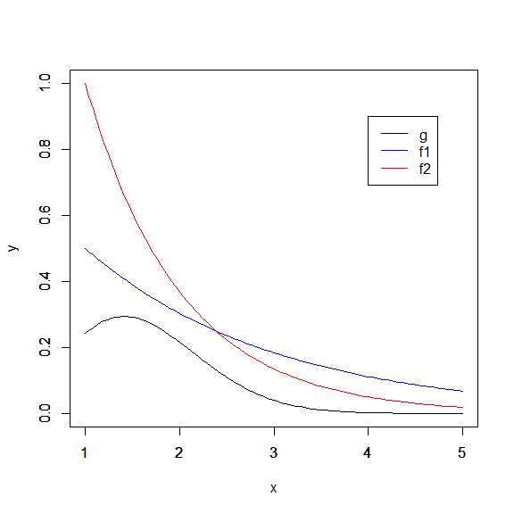

```r
set.seed(3333)
g <- function(x) x^2*exp(-x^2/2)/sqrt(2*pi)
f1 <- function(x) sqrt(exp(1))/2*exp(-x/2)
f2 <- function(x) exp(-(x-1))
plot(g,1,5,ylim=c(0,1),ylab='y')
par(new=TRUE)
plot(f1,1,5,xlab='',ylab='',main='',col='blue',ylim=c(0,1))
par(new=TRUE)
plot(f2,1,5,xlab='',ylab='',main='',col='red',ylim=c(0,1))
legend(4,0.9,c("g","f1","f2"), col = c('black','blue','red'),lwd = c(1,1,1))
```

From the figure, it seems that the most nearly constant ratio $g(x)/f(x)$ appears to be $f_2$. Thus, I might prefer $f_2$ for the smallest variance.

```r
set.seed(3333)
m <- 100000
se <- rep(0,2)
theta.hat <- rep(0,2)
g <- function(x) x^2*exp(-x^2/2)/sqrt(2*pi)
f1 <- function(x) sqrt(exp(1))/2*exp(-x/2)
f2 <- function(x) exp(-(x-1))

u1 <- runif(m,0,0.5)    # to confirm that all the x1>1
x1 <- -2*log(u1 * 2 / sqrt(exp(1)))    # f1, using inverse transform method
f1g <- g(x1)/f1(x1)
theta.hat[1] <- mean(f1g)
se[1] <- sd(f1g)

x2 <- rexp(m)+1
f2g <- g(x2)/f2(x2)
theta.hat[2] <- mean(f2g)
se[2] <- sd(f2g)

theta.hat
```

```
## [1] 0.4014080 0.4002661
```

```r
# 0.4014080 0.4002661, both are close to the real value.
se
```

```
## [1] 0.302011 0.157805
```

```r
# 0.302011 0.157805, f2 has smaller standard error, as I expected.
```

## Exercise 5.15

### Problem

Obtain the stratified importance sampling estimate in Example 5.13 and compare it with the result of Example 5.10.

### Solution

```r
set.seed(3333)
m <- 10000
g <- function(x) exp(-x - log(1+x^2))
f1 <- function(x) exp(-x)/(1-exp(-1/5))
f2 <- function(x) exp(-x)/(exp(-1/5)-exp(-2/5))
f3 <- function(x) exp(-x)/(exp(-2/5)-exp(-3/5))
f4 <- function(x) exp(-x)/(exp(-3/5)-exp(-4/5))
f5 <- function(x) exp(-x)/(exp(-4/5)-exp(-1))

u <- runif(m)
x1 <- -log(1-u*((1-exp(-1/5))))
x2 <- -log(exp(-1/5)-u*((exp(-1/5)-exp(-2/5))))
x3 <- -log(exp(-2/5)-u*((exp(-2/5)-exp(-3/5))))
x4 <- -log(exp(-3/5)-u*((exp(-3/5)-exp(-4/5))))
x5 <- -log(exp(-4/5)-u*((exp(-4/5)-exp(-1))))

fg1 <- g(x1)/f1(x1)
fg2 <- g(x2)/f2(x2)
fg3 <- g(x3)/f3(x3)
fg4 <- g(x4)/f4(x4)
fg5 <- g(x5)/f5(x5)

fg <- fg1+fg2+fg3+fg4+fg5

mean(fg)
```

```
## [1] 0.5248477
```

```r
# 0.5248477, very close to the result in Example 5.10

sd(fg)
```

```
## [1] 0.01694816
```

```r
# 0.01694816, much smaller than the result in Example 5.10
```

## Exercise 6.4

### Problem

Suppose that $X_1,...,X_n$ are a random sample from a from a lognormal distribution with unknown parameters. Construct a 95% confidence interval for the parameter $\mu$. Use a Monte Carlo method to obtain an empirical estimate of the confidence level.

### Solution

Set $n=100, m=100, \mu=5, \sigma=1$

```r
library(stats)
set.seed(3333)
n <- 100
m <- 100
l_bound <- rep(0,m)
u_bound <- rep(0,m)
for (i in 1:100) {
  x <- rlnorm(n,5,1)
  mu_hat <- sum(log(x))/n
  q <- qt(1-0.05/2,n-1)
  sigmasqu_hat <- sum((log(x)-mu_hat)^2)/n
  se_hat <- sigmasqu_hat/sqrt(n)
  l_bound[i] <- mu_hat - q*se_hat
  u_bound[i] <- mu_hat + q*se_hat
}
lb <- mean(l_bound)
ub <- mean(u_bound)
c(lb,ub)
```

```
## [1] 4.808141 5.199664
```

```r
# an empirical estimate of the confidence level is [4.808141, 5.199664], while the true value is 5.
```

## Exercise 6.5

### Problem

Suppose a 95% symmetric t-interval is applied to estimate a mean, but the sample data are non-normal. Then the probability that the confidence interval covers the mean is not necessarily equal to 0.95. Use a Monte Carlo experiment to estimate the coverage probability of the t-interval for random samples of $\chi^2(2)$ data with sample size $n = 20$. Compare your t-interval results with the simulation results in Example 6.4. (The t-interval should be more robust to departures from normality than the interval for variance.)

### Solution

Random samples of $\chi^2(2)$ data with sample size $n = 20$ is non-normal, while the random samples in Example 6.4 is normal with mean=0 and sd=2.

```r
set.seed(3333)
n <- 20
m <- 10000
lb_non <- rep(0,m)
ub_non <- rep(0,m)
lb_nor <- rep(0,m)
ub_nor <- rep(0,m)
for (i in 1:m) {
  non_normal_x <- rchisq(n,2)
  lb_non[i] <- mean(non_normal_x) - sd(non_normal_x)*qt(1-0.05/2,n-1)/sqrt(n)
  ub_non[i] <- mean(non_normal_x) + sd(non_normal_x)*qt(1-0.05/2,n-1)/sqrt(n)
  normal_x <- rnorm(n,mean=0,sd=2)
  lb_nor[i] <- mean(normal_x) - sd(normal_x)*qt(1-0.05/2,n-1)/sqrt(n)
  ub_nor[i] <- mean(normal_x) + sd(normal_x)*qt(1-0.05/2,n-1)/sqrt(n)
}
cov_prob_non <- mean(lb_non<2 & ub_non>2)
cov_prob_nor <- mean(lb_nor<0 & ub_nor>0)
c(cov_prob_non,cov_prob_nor)
```

```
## [1] 0.9173 0.9490
```

```r
# The normal samples have a coverage probability of 94.9%, which is effective. However, the non-normal samples only have a coverage probability of 91.73%, which suggests that the probability that the confidence interval covers the mean is not necessarily equal to 0.95 for non-normal samples.
```